# Risk Factor Analysis

## Outcome Variable

**Outcome Variable:** wasted

## Predictor Variables

**Intervention Variable:** exclfeed3

**Adjustment Set:**

- arm
- sex
- W_mage
- meducyrs
- feducyrs
- hhwealth_quart
- hfoodsec
- W_mhtcm
- vagbrth
- W_gagebrth
- W_birthwt
- W_birthlen
- W_nrooms
- W_nchldlt5
- month
- brthmon
- W_parity
- impfloor
- impsan
- safeh20
- delta_W_mage
- delta_meducyrs
- delta_feducyrs
- delta_hhwealth_quart
- delta_hfoodsec
- delta_W_mhtcm
- delta_vagbrth
- delta_W_gagebrth
- delta_W_birthwt
- delta_W_birthlen
- delta_W_nrooms
- delta_W_nchldlt5
- delta_month
- delta_brthmon
- delta_W_parity
- delta_impfloor
- delta_impsan
- delta_safeh20

## Stratifying Variables

The analysis was stratified on these variable(s):

- agecat
- studyid
- country

## Data Summary

| agecat | studyid | country | exclfeed3 | wasted | n_cell | n |
| --- | --- | --- | --- | --- | --- | --- |
| Birth | ki0047075b-MAL-ED | BANGLADESH | 1 | 0 | 135 | 227 |
| Birth | ki0047075b-MAL-ED | BANGLADESH | 1 | 1 | 29 | 227 |
| Birth | ki0047075b-MAL-ED | BANGLADESH | 0 | 0 | 54 | 227 |
| Birth | ki0047075b-MAL-ED | BANGLADESH | 0 | 1 | 9 | 227 |
| Birth | ki0047075b-MAL-ED | BRAZIL | 1 | 0 | 63 | 177 |
| Birth | ki0047075b-MAL-ED | BRAZIL | 1 | 1 | 2 | 177 |
| Birth | ki0047075b-MAL-ED | BRAZIL | 0 | 0 | 108 | 177 |
| Birth | ki0047075b-MAL-ED | BRAZIL | 0 | 1 | 4 | 177 |
| Birth | ki0047075b-MAL-ED | INDIA | 1 | 0 | 103 | 193 |
| Birth | ki0047075b-MAL-ED | INDIA | 1 | 1 | 18 | 193 |
| Birth | ki0047075b-MAL-ED | INDIA | 0 | 0 | 57 | 193 |
| Birth | ki0047075b-MAL-ED | INDIA | 0 | 1 | 15 | 193 |
| Birth | ki0047075b-MAL-ED | NEPAL | 1 | 0 | 55 | 166 |
| Birth | ki0047075b-MAL-ED | NEPAL | 1 | 1 | 5 | 166 |
| Birth | ki0047075b-MAL-ED | NEPAL | 0 | 0 | 91 | 166 |
| Birth | ki0047075b-MAL-ED | NEPAL | 0 | 1 | 15 | 166 |
| Birth | ki0047075b-MAL-ED | PERU | 1 | 0 | 64 | 265 |
| Birth | ki0047075b-MAL-ED | PERU | 1 | 1 | 0 | 265 |
| Birth | ki0047075b-MAL-ED | PERU | 0 | 0 | 195 | 265 |
| Birth | ki0047075b-MAL-ED | PERU | 0 | 1 | 6 | 265 |
| Birth | ki0047075b-MAL-ED | SOUTH AFRICA | 1 | 0 | 32 | 231 |
| Birth | ki0047075b-MAL-ED | SOUTH AFRICA | 1 | 1 | 0 | 231 |
| Birth | ki0047075b-MAL-ED | SOUTH AFRICA | 0 | 0 | 185 | 231 |
| Birth | ki0047075b-MAL-ED | SOUTH AFRICA | 0 | 1 | 14 | 231 |
| Birth | ki0047075b-MAL-ED | TANZANIA, UNITED REPUBLIC OF | 1 | 0 | 38 | 114 |
| Birth | ki0047075b-MAL-ED | TANZANIA, UNITED REPUBLIC OF | 1 | 1 | 0 | 114 |
| Birth | ki0047075b-MAL-ED | TANZANIA, UNITED REPUBLIC OF | 0 | 0 | 74 | 114 |
| Birth | ki0047075b-MAL-ED | TANZANIA, UNITED REPUBLIC OF | 0 | 1 | 2 | 114 |
| Birth | ki1000108-CMC-V-BCS-2002 | INDIA | 1 | 0 | 4 | 4 |
| Birth | ki1000108-CMC-V-BCS-2002 | INDIA | 1 | 1 | 0 | 4 |

[output cut: 146 more lines]

The following strata were considered:

- agecat: 24 months, studyid: ki0047075b-MAL-ED, country: BANGLADESH
- agecat: 24 months, studyid: ki0047075b-MAL-ED, country: BRAZIL
- agecat: 24 months, studyid: ki0047075b-MAL-ED, country: INDIA
- agecat: 24 months, studyid: ki0047075b-MAL-ED, country: NEPAL
- agecat: 24 months, studyid: ki0047075b-MAL-ED, country: PERU
- agecat: 24 months, studyid: ki0047075b-MAL-ED, country: SOUTH AFRICA
- agecat: 24 months, studyid: ki0047075b-MAL-ED, country: TANZANIA, UNITED REPUBLIC OF
- agecat: 24 months, studyid: ki1000108-CMC-V-BCS-2002, country: INDIA
- agecat: 24 months, studyid: ki1000108-IRC, country: INDIA
- agecat: 24 months, studyid: ki1017093b-PROVIDE, country: BANGLADESH
- agecat: 24 months, studyid: ki1101329-Keneba, country: GAMBIA
- agecat: 24 months, studyid: ki1113344-GMS-Nepal, country: NEPAL
- agecat: 24 months, studyid: kiGH5241-JiVitA-3, country: BANGLADESH
- agecat: 24 months, studyid: kiGH5241-JiVitA-4, country: BANGLADESH
- agecat: 6 months, studyid: ki0047075b-MAL-ED, country: BANGLADESH
- agecat: 6 months, studyid: ki0047075b-MAL-ED, country: BRAZIL
- agecat: 6 months, studyid: ki0047075b-MAL-ED, country: INDIA
- agecat: 6 months, studyid: ki0047075b-MAL-ED, country: NEPAL
- agecat: 6 months, studyid: ki0047075b-MAL-ED, country: PERU
- agecat: 6 months, studyid: ki0047075b-MAL-ED, country: SOUTH AFRICA
- agecat: 6 months, studyid: ki0047075b-MAL-ED, country: TANZANIA, UNITED REPUBLIC OF
- agecat: 6 months, studyid: ki1000108-CMC-V-BCS-2002, country: INDIA
- agecat: 6 months, studyid: ki1000108-IRC, country: INDIA
- agecat: 6 months, studyid: ki1000109-EE, country: PAKISTAN
- agecat: 6 months, studyid: ki1000304b-SAS-CompFeed, country: INDIA
- agecat: 6 months, studyid: ki1017093b-PROVIDE, country: BANGLADESH
- agecat: 6 months, studyid: ki1101329-Keneba, country: GAMBIA
- agecat: 6 months, studyid: ki1113344-GMS-Nepal, country: NEPAL
- agecat: 6 months, studyid: kiGH5241-JiVitA-3, country: BANGLADESH
- agecat: 6 months, studyid: kiGH5241-JiVitA-4, country: BANGLADESH
- agecat: Birth, studyid: ki0047075b-MAL-ED, country: BANGLADESH
- agecat: Birth, studyid: ki0047075b-MAL-ED, country: BRAZIL
- agecat: Birth, studyid: ki0047075b-MAL-ED, country: INDIA
- agecat: Birth, studyid: ki0047075b-MAL-ED, country: NEPAL
- agecat: Birth, studyid: ki0047075b-MAL-ED, country: PERU
- agecat: Birth, studyid: ki0047075b-MAL-ED, country: SOUTH AFRICA
- agecat: Birth, studyid: ki0047075b-MAL-ED, country: TANZANIA, UNITED REPUBLIC OF
- agecat: Birth, studyid: ki1000108-CMC-V-BCS-2002, country: INDIA
- agecat: Birth, studyid: ki1000108-IRC, country: INDIA
- agecat: Birth, studyid: ki1000109-EE, country: PAKISTAN
- agecat: Birth, studyid: ki1000304b-SAS-CompFeed, country: INDIA
- agecat: Birth, studyid: ki1101329-Keneba, country: GAMBIA
- agecat: Birth, studyid: kiGH5241-JiVitA-3, country: BANGLADESH
- agecat: Birth, studyid: kiGH5241-JiVitA-4, country: BANGLADESH

### Dropped Strata

Some strata were dropped due to rare outcomes:

- agecat: Birth, studyid: ki0047075b-MAL-ED, country: BRAZIL
- agecat: Birth, studyid: ki0047075b-MAL-ED, country: PERU
- agecat: Birth, studyid: ki0047075b-MAL-ED, country: SOUTH AFRICA
- agecat: Birth, studyid: ki0047075b-MAL-ED, country: TANZANIA, UNITED REPUBLIC OF
- agecat: Birth, studyid: ki1000108-CMC-V-BCS-2002, country: INDIA
- agecat: Birth, studyid: ki1000108-IRC, country: INDIA
- agecat: Birth, studyid: ki1000109-EE, country: PAKISTAN
- agecat: Birth, studyid: ki1000304b-SAS-CompFeed, country: INDIA
- agecat: Birth, studyid: kiGH5241-JiVitA-4, country: BANGLADESH
- agecat: 6 months, studyid: ki0047075b-MAL-ED, country: BANGLADESH
- agecat: 6 months, studyid: ki0047075b-MAL-ED, country: BRAZIL
- agecat: 6 months, studyid: ki0047075b-MAL-ED, country: NEPAL
- agecat: 6 months, studyid: ki0047075b-MAL-ED, country: PERU
- agecat: 6 months, studyid: ki0047075b-MAL-ED, country: SOUTH AFRICA
- agecat: 6 months, studyid: ki0047075b-MAL-ED, country: TANZANIA, UNITED REPUBLIC OF
- agecat: 6 months, studyid: ki1000108-CMC-V-BCS-2002, country: INDIA
- agecat: 6 months, studyid: ki1000108-IRC, country: INDIA
- agecat: 6 months, studyid: ki1000304b-SAS-CompFeed, country: INDIA
- agecat: 6 months, studyid: kiGH5241-JiVitA-4, country: BANGLADESH
- agecat: 24 months, studyid: ki0047075b-MAL-ED, country: BANGLADESH
- agecat: 24 months, studyid: ki0047075b-MAL-ED, country: BRAZIL
- agecat: 24 months, studyid: ki0047075b-MAL-ED, country: NEPAL
- agecat: 24 months, studyid: ki0047075b-MAL-ED, country: PERU
- agecat: 24 months, studyid: ki0047075b-MAL-ED, country: SOUTH AFRICA
- agecat: 24 months, studyid: ki0047075b-MAL-ED, country: TANZANIA, UNITED REPUBLIC OF
- agecat: 24 months, studyid: ki1000108-CMC-V-BCS-2002, country: INDIA
- agecat: 24 months, studyid: ki1000108-IRC, country: INDIA
- agecat: 24 months, studyid: kiGH5241-JiVitA-4, country: BANGLADESH

## Methods Detail

We’re interested in the causal parameters $E[Y_a]$ for all values of $a \in \mathcal{A}$. These parameters represent the mean outcome if, possibly contrary to fact, we intervened to set all units to have $A=a$. Under the randomization and positivity assumptions, these are identified by the statistical parameters $\psi_a=E_W[E_{Y|A,W}(Y|A=a,W)]$. In addition, we’re interested in the mean of $Y$, $E[Y]$ under no intervention (the observed mean). We will estimate these parameters by using SuperLearner to fit the relevant likelihood factors – $E_{Y|A,W}(Y|A=a,W)$ and $p(A=a|W)$, and then updating our likelihood fit using a joint TMLE.

For unadjusted analyses ($W=\{\}$), initial likelihoods were estimated using Lrnr_glm to estimate the simple $E(Y|A)$ and Lrnr_mean to estimate $p(A)$. For adjusted analyses, a small library containing Lrnr_glmnet, Lrnr_xgboost, and Lrnr_mean was used.

Having estimated these parameters, we will then use the delta method to estimate relative risks and attributable risks relative to a prespecified baseline level of $A$.

# Results Detail

## Results Plots

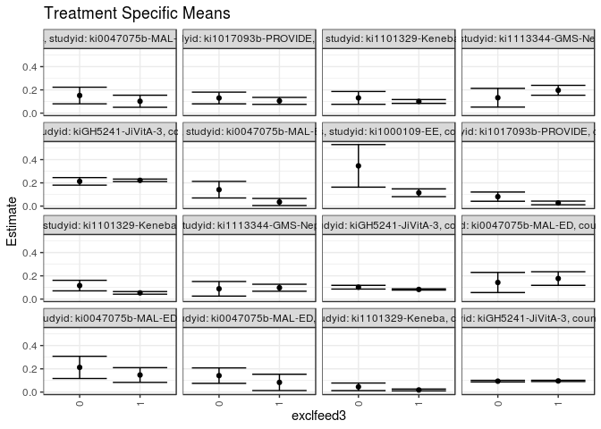

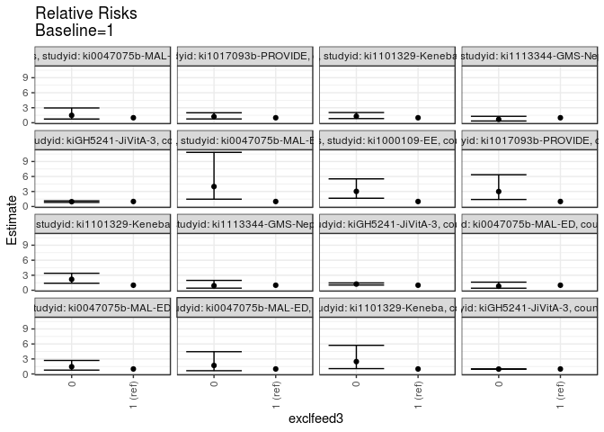

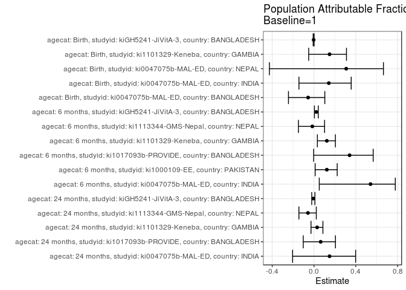

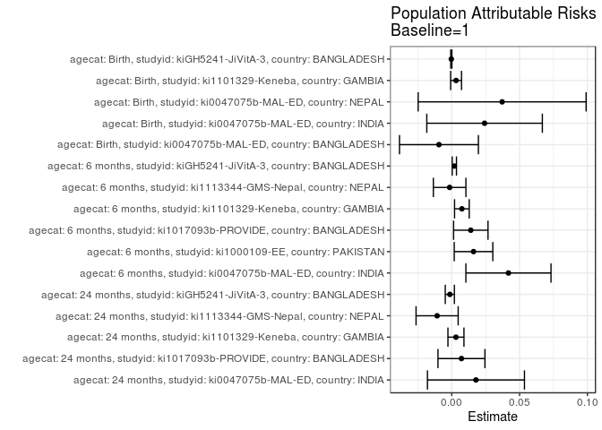

## Results Table

### Parameter: TSM

| agecat | studyid | country | intervention_level | baseline_level | estimate | ci_lower | ci_upper |
| --- | --- | --- | --- | --- | --- | --- | --- |
| Birth | ki0047075b-MAL-ED | BANGLADESH | 1 | NA | 0.1768293 | 0.1183089 | 0.2353496 |
| Birth | ki0047075b-MAL-ED | BANGLADESH | 0 | NA | 0.1428571 | 0.0562579 | 0.2294564 |
| Birth | ki0047075b-MAL-ED | INDIA | 1 | NA | 0.1467833 | 0.0835022 | 0.2100645 |
| Birth | ki0047075b-MAL-ED | INDIA | 0 | NA | 0.2123320 | 0.1166144 | 0.3080496 |
| Birth | ki0047075b-MAL-ED | NEPAL | 1 | NA | 0.0833333 | 0.0131879 | 0.1534788 |
| Birth | ki0047075b-MAL-ED | NEPAL | 0 | NA | 0.1415094 | 0.0749564 | 0.2080624 |
| Birth | ki1101329-Keneba | GAMBIA | 1 | NA | 0.0182609 | 0.0105194 | 0.0260024 |
| Birth | ki1101329-Keneba | GAMBIA | 0 | NA | 0.0451613 | 0.0124576 | 0.0778650 |
| Birth | kiGH5241-JiVitA-3 | BANGLADESH | 1 | NA | 0.0958507 | 0.0905881 | 0.1011132 |
| Birth | kiGH5241-JiVitA-3 | BANGLADESH | 0 | NA | 0.0938732 | 0.0870898 | 0.1006566 |
| 6 months | ki0047075b-MAL-ED | INDIA | 1 | NA | 0.0354610 | 0.0048690 | 0.0660530 |
| 6 months | ki0047075b-MAL-ED | INDIA | 0 | NA | 0.1413043 | 0.0699722 | 0.2126365 |
| 6 months | ki1000109-EE | PAKISTAN | 1 | NA | 0.1146132 | 0.0811475 | 0.1480788 |
| 6 months | ki1000109-EE | PAKISTAN | 0 | NA | 0.3461538 | 0.1630432 | 0.5292645 |
| 6 months | ki1017093b-PROVIDE | BANGLADESH | 1 | NA | 0.0271936 | 0.0115989 | 0.0427883 |
| 6 months | ki1017093b-PROVIDE | BANGLADESH | 0 | NA | 0.0813222 | 0.0416317 | 0.1210127 |
| 6 months | ki1101329-Keneba | GAMBIA | 1 | NA | 0.0533754 | 0.0421322 | 0.0646186 |
| 6 months | ki1101329-Keneba | GAMBIA | 0 | NA | 0.1161921 | 0.0708474 | 0.1615368 |
| 6 months | ki1113344-GMS-Nepal | NEPAL | 1 | NA | 0.0976253 | 0.0677111 | 0.1275396 |
| 6 months | ki1113344-GMS-Nepal | NEPAL | 0 | NA | 0.0886076 | 0.0258744 | 0.1513408 |
| 6 months | kiGH5241-JiVitA-3 | BANGLADESH | 1 | NA | 0.0829333 | 0.0778329 | 0.0880338 |
| 6 months | kiGH5241-JiVitA-3 | BANGLADESH | 0 | NA | 0.1021659 | 0.0860513 | 0.1182805 |
| 24 months | ki0047075b-MAL-ED | INDIA | 1 | NA | 0.1021524 | 0.0502357 | 0.1540692 |
| 24 months | ki0047075b-MAL-ED | INDIA | 0 | NA | 0.1514996 | 0.0801160 | 0.2228832 |
| 24 months | ki1017093b-PROVIDE | BANGLADESH | 1 | NA | 0.1052918 | 0.0753656 | 0.1352181 |
| 24 months | ki1017093b-PROVIDE | BANGLADESH | 0 | NA | 0.1300263 | 0.0797091 | 0.1803435 |
| 24 months | ki1101329-Keneba | GAMBIA | 1 | NA | 0.1003475 | 0.0838305 | 0.1168645 |
| 24 months | ki1101329-Keneba | GAMBIA | 0 | NA | 0.1309430 | 0.0760206 | 0.1858655 |
| 24 months | ki1113344-GMS-Nepal | NEPAL | 1 | NA | 0.1964286 | 0.1538951 | 0.2389621 |
| 24 months | ki1113344-GMS-Nepal | NEPAL | 0 | NA | 0.1323529 | 0.0517093 | 0.2129966 |
| 24 months | kiGH5241-JiVitA-3 | BANGLADESH | 1 | NA | 0.2215416 | 0.2107718 | 0.2323114 |
| 24 months | kiGH5241-JiVitA-3 | BANGLADESH | 0 | NA | 0.2126490 | 0.1801302 | 0.2451677 |

### Parameter: E(Y)

| agecat | studyid | country | intervention_level | baseline_level | estimate | ci_lower | ci_upper |
| --- | --- | --- | --- | --- | --- | --- | --- |
| Birth | ki0047075b-MAL-ED | BANGLADESH | NA | NA | 0.1674009 | 0.1187276 | 0.2160742 |
| Birth | ki0047075b-MAL-ED | INDIA | NA | NA | 0.1709845 | 0.1177299 | 0.2242391 |
| Birth | ki0047075b-MAL-ED | NEPAL | NA | NA | 0.1204819 | 0.0708125 | 0.1701514 |
| Birth | ki1101329-Keneba | GAMBIA | NA | NA | 0.0214559 | 0.0135914 | 0.0293205 |
| Birth | kiGH5241-JiVitA-3 | BANGLADESH | NA | NA | 0.0955338 | 0.0902714 | 0.1007962 |
| 6 months | ki0047075b-MAL-ED | INDIA | NA | NA | 0.0772532 | 0.0428971 | 0.1116093 |
| 6 months | ki1000109-EE | PAKISTAN | NA | NA | 0.1306667 | 0.0965090 | 0.1648243 |
| 6 months | ki1017093b-PROVIDE | BANGLADESH | NA | NA | 0.0412371 | 0.0250690 | 0.0574052 |
| 6 months | ki1101329-Keneba | GAMBIA | NA | NA | 0.0608496 | 0.0496205 | 0.0720787 |
| 6 months | ki1113344-GMS-Nepal | NEPAL | NA | NA | 0.0960699 | 0.0690520 | 0.1230877 |
| 6 months | kiGH5241-JiVitA-3 | BANGLADESH | NA | NA | 0.0848459 | 0.0799494 | 0.0897424 |
| 24 months | ki0047075b-MAL-ED | INDIA | NA | NA | 0.1200000 | 0.0774445 | 0.1625555 |
| 24 months | ki1017093b-PROVIDE | BANGLADESH | NA | NA | 0.1124567 | 0.0866788 | 0.1382347 |
| 24 months | ki1101329-Keneba | GAMBIA | NA | NA | 0.1034483 | 0.0876083 | 0.1192882 |
| 24 months | ki1113344-GMS-Nepal | NEPAL | NA | NA | 0.1856436 | 0.1476821 | 0.2236050 |
| 24 months | kiGH5241-JiVitA-3 | BANGLADESH | NA | NA | 0.2201371 | 0.2099559 | 0.2303184 |

### Parameter: RR

| agecat | studyid | country | intervention_level | baseline_level | estimate | ci_lower | ci_upper |
| --- | --- | --- | --- | --- | --- | --- | --- |
| Birth | ki0047075b-MAL-ED | BANGLADESH | 1 | 1 | 1.0000000 | 1.0000000 | 1.000000 |
| Birth | ki0047075b-MAL-ED | BANGLADESH | 0 | 1 | 0.8078818 | 0.4049515 | 1.611731 |
| Birth | ki0047075b-MAL-ED | INDIA | 1 | 1 | 1.0000000 | 1.0000000 | 1.000000 |
| Birth | ki0047075b-MAL-ED | INDIA | 0 | 1 | 1.4465674 | 0.7742197 | 2.702795 |
| Birth | ki0047075b-MAL-ED | NEPAL | 1 | 1 | 1.0000000 | 1.0000000 | 1.000000 |
| Birth | ki0047075b-MAL-ED | NEPAL | 0 | 1 | 1.6981132 | 0.6474557 | 4.453723 |
| Birth | ki1101329-Keneba | GAMBIA | 1 | 1 | 1.0000000 | 1.0000000 | 1.000000 |
| Birth | ki1101329-Keneba | GAMBIA | 0 | 1 | 2.4731182 | 1.0686114 | 5.723609 |
| Birth | kiGH5241-JiVitA-3 | BANGLADESH | 1 | 1 | 1.0000000 | 1.0000000 | 1.000000 |
| Birth | kiGH5241-JiVitA-3 | BANGLADESH | 0 | 1 | 0.9793691 | 0.9344865 | 1.026407 |
| 6 months | ki0047075b-MAL-ED | INDIA | 1 | 1 | 1.0000000 | 1.0000000 | 1.000000 |
| 6 months | ki0047075b-MAL-ED | INDIA | 0 | 1 | 3.9847826 | 1.4665964 | 10.826764 |
| 6 months | ki1000109-EE | PAKISTAN | 1 | 1 | 1.0000000 | 1.0000000 | 1.000000 |
| 6 months | ki1000109-EE | PAKISTAN | 0 | 1 | 3.0201923 | 1.6505346 | 5.526428 |
| 6 months | ki1017093b-PROVIDE | BANGLADESH | 1 | 1 | 1.0000000 | 1.0000000 | 1.000000 |
| 6 months | ki1017093b-PROVIDE | BANGLADESH | 0 | 1 | 2.9904921 | 1.4076919 | 6.352983 |
| 6 months | ki1101329-Keneba | GAMBIA | 1 | 1 | 1.0000000 | 1.0000000 | 1.000000 |
| 6 months | ki1101329-Keneba | GAMBIA | 0 | 1 | 2.1768849 | 1.3976105 | 3.390664 |
| 6 months | ki1113344-GMS-Nepal | NEPAL | 1 | 1 | 1.0000000 | 1.0000000 | 1.000000 |
| 6 months | ki1113344-GMS-Nepal | NEPAL | 0 | 1 | 0.9076291 | 0.4196337 | 1.963118 |
| 6 months | kiGH5241-JiVitA-3 | BANGLADESH | 1 | 1 | 1.0000000 | 1.0000000 | 1.000000 |
| 6 months | kiGH5241-JiVitA-3 | BANGLADESH | 0 | 1 | 1.2319036 | 1.0428749 | 1.455195 |
| 24 months | ki0047075b-MAL-ED | INDIA | 1 | 1 | 1.0000000 | 1.0000000 | 1.000000 |
| 24 months | ki0047075b-MAL-ED | INDIA | 0 | 1 | 1.4830739 | 0.7432233 | 2.959418 |
| 24 months | ki1017093b-PROVIDE | BANGLADESH | 1 | 1 | 1.0000000 | 1.0000000 | 1.000000 |
| 24 months | ki1017093b-PROVIDE | BANGLADESH | 0 | 1 | 1.2349134 | 0.7643867 | 1.995078 |
| 24 months | ki1101329-Keneba | GAMBIA | 1 | 1 | 1.0000000 | 1.0000000 | 1.000000 |
| 24 months | ki1101329-Keneba | GAMBIA | 0 | 1 | 1.3048956 | 0.8316923 | 2.047335 |
| 24 months | ki1113344-GMS-Nepal | NEPAL | 1 | 1 | 1.0000000 | 1.0000000 | 1.000000 |
| 24 months | ki1113344-GMS-Nepal | NEPAL | 0 | 1 | 0.6737968 | 0.3529368 | 1.286355 |
| 24 months | kiGH5241-JiVitA-3 | BANGLADESH | 1 | 1 | 1.0000000 | 1.0000000 | 1.000000 |
| 24 months | kiGH5241-JiVitA-3 | BANGLADESH | 0 | 1 | 0.9598603 | 0.8175294 | 1.126971 |

### Parameter: PAR

| agecat | studyid | country | intervention_level | baseline_level | estimate | ci_lower | ci_upper |
| --- | --- | --- | --- | --- | --- | --- | --- |
| Birth | ki0047075b-MAL-ED | BANGLADESH | 1 | NA | -0.0094284 | -0.0385034 | 0.0196466 |
| Birth | ki0047075b-MAL-ED | INDIA | 1 | NA | 0.0242011 | -0.0183814 | 0.0667836 |
| Birth | ki0047075b-MAL-ED | NEPAL | 1 | NA | 0.0371486 | -0.0247427 | 0.0990399 |
| Birth | ki1101329-Keneba | GAMBIA | 1 | NA | 0.0031951 | -0.0008245 | 0.0072146 |
| Birth | kiGH5241-JiVitA-3 | BANGLADESH | 1 | NA | -0.0003168 | -0.0007604 | 0.0001267 |
| 6 months | ki0047075b-MAL-ED | INDIA | 1 | NA | 0.0417922 | 0.0104310 | 0.0731535 |
| 6 months | ki1000109-EE | PAKISTAN | 1 | NA | 0.0160535 | 0.0018375 | 0.0302695 |
| 6 months | ki1017093b-PROVIDE | BANGLADESH | 1 | NA | 0.0140435 | 0.0013639 | 0.0267231 |
| 6 months | ki1101329-Keneba | GAMBIA | 1 | NA | 0.0074742 | 0.0020781 | 0.0128703 |
| 6 months | ki1113344-GMS-Nepal | NEPAL | 1 | NA | -0.0015555 | -0.0135476 | 0.0104367 |
| 6 months | kiGH5241-JiVitA-3 | BANGLADESH | 1 | NA | 0.0019125 | 0.0003426 | 0.0034824 |
| 24 months | ki0047075b-MAL-ED | INDIA | 1 | NA | 0.0178476 | -0.0179028 | 0.0535979 |
| 24 months | ki1017093b-PROVIDE | BANGLADESH | 1 | NA | 0.0071649 | -0.0101412 | 0.0244710 |
| 24 months | ki1101329-Keneba | GAMBIA | 1 | NA | 0.0031008 | -0.0028012 | 0.0090027 |
| 24 months | ki1113344-GMS-Nepal | NEPAL | 1 | NA | -0.0107850 | -0.0263084 | 0.0047384 |
| 24 months | kiGH5241-JiVitA-3 | BANGLADESH | 1 | NA | -0.0014044 | -0.0047592 | 0.0019504 |

### Parameter: PAF

| agecat | studyid | country | intervention_level | baseline_level | estimate | ci_lower | ci_upper |
| --- | --- | --- | --- | --- | --- | --- | --- |
| Birth | ki0047075b-MAL-ED | BANGLADESH | 1 | NA | -0.0563222 | -0.2445778 | 0.1034577 |
| Birth | ki0047075b-MAL-ED | INDIA | 1 | NA | 0.1415398 | -0.1442165 | 0.3559314 |
| Birth | ki0047075b-MAL-ED | NEPAL | 1 | NA | 0.3083333 | -0.4267249 | 0.6646846 |
| Birth | ki1101329-Keneba | GAMBIA | 1 | NA | 0.1489130 | -0.0509463 | 0.3107650 |
| Birth | kiGH5241-JiVitA-3 | BANGLADESH | 1 | NA | -0.0033166 | -0.0079815 | 0.0013267 |
| 6 months | ki0047075b-MAL-ED | INDIA | 1 | NA | 0.5409771 | 0.0503299 | 0.7781314 |
| 6 months | ki1000109-EE | PAKISTAN | 1 | NA | 0.1228583 | 0.0110358 | 0.2220370 |
| 6 months | ki1017093b-PROVIDE | BANGLADESH | 1 | NA | 0.3405554 | -0.0031464 | 0.5664968 |
| 6 months | ki1101329-Keneba | GAMBIA | 1 | NA | 0.1228307 | 0.0323042 | 0.2048885 |
| 6 months | ki1113344-GMS-Nepal | NEPAL | 1 | NA | -0.0161909 | -0.1489352 | 0.1012165 |
| 6 months | kiGH5241-JiVitA-3 | BANGLADESH | 1 | NA | 0.0225413 | 0.0038521 | 0.0408798 |
| 24 months | ki0047075b-MAL-ED | INDIA | 1 | NA | 0.1487296 | -0.2049088 | 0.3985758 |
| 24 months | ki1017093b-PROVIDE | BANGLADESH | 1 | NA | 0.0637128 | -0.1030439 | 0.2052594 |
| 24 months | ki1101329-Keneba | GAMBIA | 1 | NA | 0.0299742 | -0.0286484 | 0.0852558 |
| 24 months | ki1113344-GMS-Nepal | NEPAL | 1 | NA | -0.0580952 | -0.1446338 | 0.0219007 |
| 24 months | kiGH5241-JiVitA-3 | BANGLADESH | 1 | NA | -0.0063798 | -0.0217335 | 0.0087432 |